# Homework 3: Confidence Intervals

**Load some handy packages:**

```r
suppressPackageStartupMessages(library(dplyr))
suppressPackageStartupMessages(library(ggplot2))
```

## Constructing Confidence Intervals

```r
sleep = read.csv("https://www.macalester.edu/~ajohns24/Data/SleepStudy2.csv")
head(sleep, 2)
```

```
##   X Subject   Day0   Day2 Difference
## 1 1       1 249.56 250.80       1.24
## 2 2       2 222.73 202.98     -19.75
```

### Exercise 1

```r
n = nrow(sleep)
mean(sleep$Difference)
```

```
## [1] 8.710556
```

```r
sd(sleep$Difference)/sqrt(n)
```

```
## [1] 7.494941
```

1c 95%, 5%

### Exercise 2

2a. 95%  
2b

```r
mean(sleep$Difference) + 2*sd(sleep$Difference)/sqrt(n)
```

```
## [1] 23.70044
```

```r
mean(sleep$Difference) - 2*sd(sleep$Difference)/sqrt(n)
```

```
## [1] -6.279327
```

2c.

```r
t.test(sleep$Difference, conf.level=0.95)
```

```
##
##  One Sample t-test
##
## data:  sleep$Difference
## t = 1.1622, df = 17, p-value = 0.2612
## alternative hypothesis: true mean is not equal to 0
## 95 percent confidence interval:
##  -7.102388 24.523499
## sample estimates:
## mean of x
##  8.710556
```

### Exercise 3

Yes. 0 falls within the confidence interval. Thus, our data don’t signifcantly support the claim that that the average reaction time after 2 days of sleep deprivation is greater (slower) than after 0 days of sleep deprivation.

## Interpreting Confidence Level

```r
#attach the library
suppressPackageStartupMessages(library(gapminder))

#load the data
data(gapminder)

#examine the codebook
?gapminder
```

```
## starting httpd help server ...
```

```
##  done
```

### Exercise 4

```r
#4a. Number of cases
nrow(gapminder)
```

```
## [1] 1704
```

```r
#4b For what years do we have data?
unique(gapminder$year)
```

```
##  [1] 1952 1957 1962 1967 1972 1977 1982 1987 1992 1997 2002 2007
```

```r
#4c For how many different countries do we have data?
length(unique(gapminder$country))
```

```
## [1] 142
```

4a. Each case represent is Country’s life expectancy and gpa per capita for a particular year along with the continent it belongs to.

### Exercise 5

5a

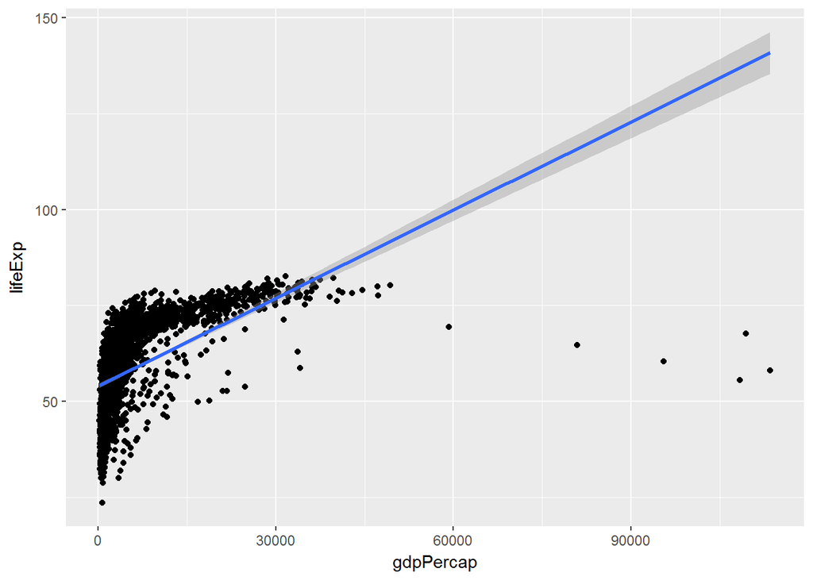

```r
gapminder%>% ggplot(aes(y = lifeExp, x= gdpPercap)) + geom_point() + geom_smooth(method = 'lm')
```

5b. Data points are not independent. Afghanistan’s lifeExp (GDP) is dependent on previous year’s lifeExp (GDP). Also, residuals are not normally distributed with mean zero. (lack of fit)

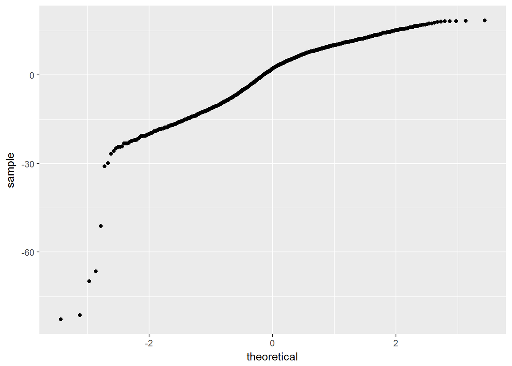

```r
mod <- lm( lifeExp ~ gdpPercap, gapminder )
ModResults <- data.frame(observed = gapminder$lifeExp, predicted = mod$fitted.values, residual = mod$residuals)
ggplot(ModResults, aes(sample=residual)) +
    geom_qq()
```

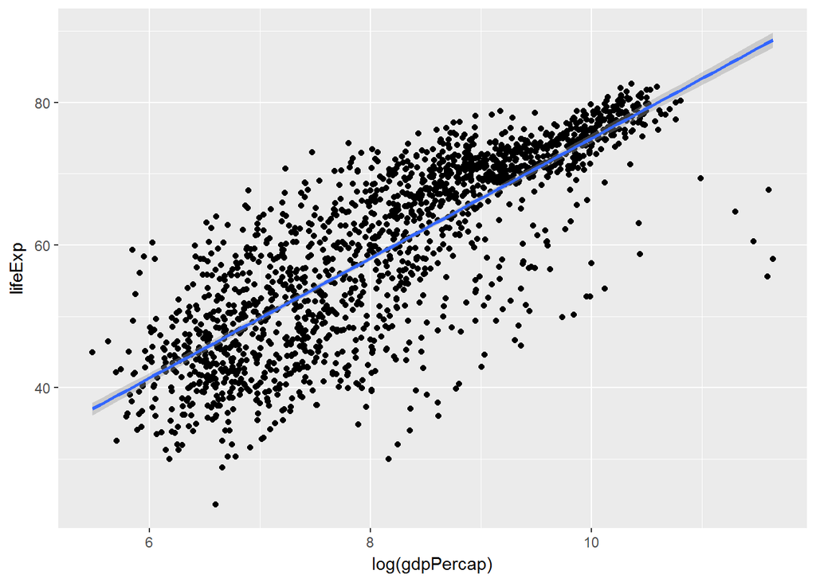

```r
gapminder%>% ggplot(aes(y = lifeExp, x= log(gdpPercap))) + geom_point() + geom_smooth(method = 'lm')
```

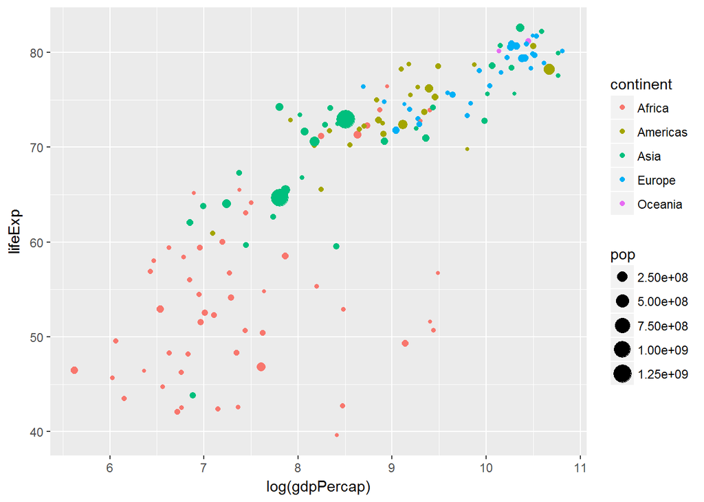

```r
gap2007 <- gapminder %>%
    filter(year==2007)

gap2007 %>% ggplot(aes(x = log(gdpPercap), y = lifeExp, color = continent, size = pop)) + geom_point()
```

### Exercise 6

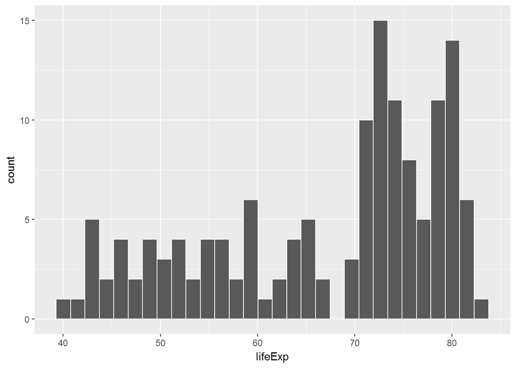

```r
ggplot(gap2007, aes(x=lifeExp)) +
    geom_histogram(color="white")
```

```r
mean(gap2007$lifeExp)
```

```
## [1] 67.00742
```

```r
#set the seed
set.seed(39)

#take a sample
samp1 <- sample_n(gap2007, size=25)

#calculate the sample mean & sd
mean(samp1$lifeExp)
```

```
## [1] 72.49796
```

```r
## [1] 72.5
sd(samp1$lifeExp)
```

```
## [1] 9.723725
```

```r
## [1] 9.724
```

```r
mean(samp1$lifeExp)+ 2*sd(samp1$lifeExp)/sqrt(25)
```

```
## [1] 76.38745
```

```r
mean(samp1$lifeExp)- 2*sd(samp1$lifeExp)/sqrt(25)
```

```
## [1] 68.60847
```

```r
t.test(samp1$lifeExp, conf.level=0.95)
```

```
##
##  One Sample t-test
##
## data:  samp1$lifeExp
## t = 37.279, df = 24, p-value < 2.2e-16
## alternative hypothesis: true mean is not equal to 0
## 95 percent confidence interval:
##  68.48420 76.51172
## sample estimates:
## mean of x
##  72.49796
```

6c. No. True mean falls outside our CI

### Exercise 7

```r
#set the seed
set.seed(90)

#initialize the for loop
CIsimulation <- data.frame(lower=rep(0,100), upper=rep(0,100))


#run the for loop
for(i in 1:100){
    samp <- sample_n(gap2007, size=25)
    CIsimulation[i,] <- t.test(samp$lifeExp, conf.level=0.95)$conf.int
}
```

7b.

```r
CIsimulation <- CIsimulation %>% mutate(experiment = c(1:100), cover = (lower < 67.00742) & (upper > 67.00742))
```

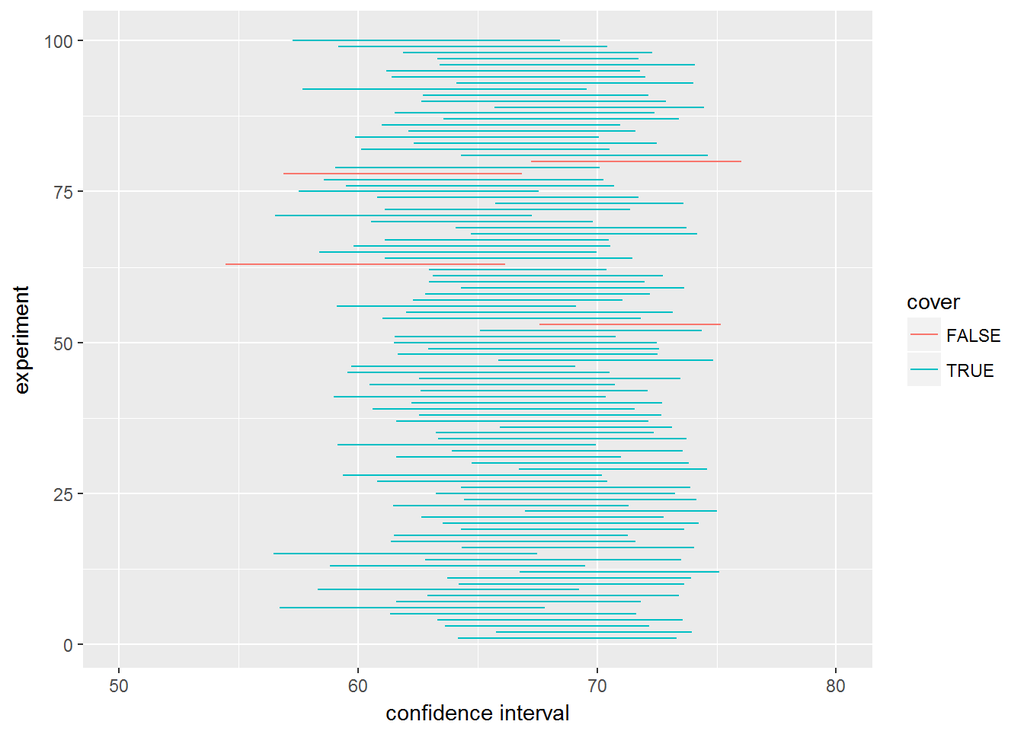

```r
ggplot(CIsimulation, aes(y=experiment, x=lower, color=cover)) +
    geom_segment(aes(x=lower, xend=upper, y=experiment, yend=experiment)) +
    labs(x="confidence interval") +
    lims(x=c(50,80))
```

```r
CIcovered <- CIsimulation %>% filter(cover == TRUE)
nrow(CIcovered)
```

```
## [1] 96
```

### Exercise 8

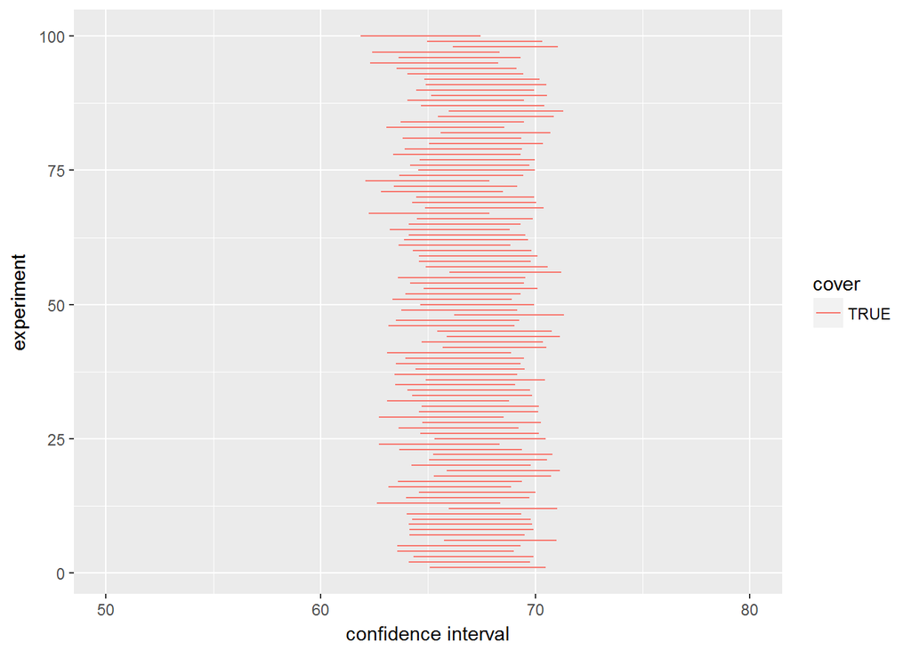

```r
#set the seed
set.seed(90)

#initialize the for loop
CIsimulation <- data.frame(lower=rep(0,100), upper=rep(0,100))


#run the for loop
for(i in 1:100){
    samp <- sample_n(gap2007, size=75)
    CIsimulation[i,] <- t.test(samp$lifeExp, conf.level=0.95)$conf.int
}


CIsimulation <- CIsimulation %>% mutate(experiment = c(1:100), cover = (lower < 67.00742) & (upper > 67.00742))

ggplot(CIsimulation, aes(y=experiment, x=lower, color=cover)) +
    geom_segment(aes(x=lower, xend=upper, y=experiment, yend=experiment)) +
    labs(x="confidence interval") +
    lims(x=c(50,80))
```

Larger sample size = narrower CI

### Exercise 9

Narrower but inaccurate as it is only 68% CI

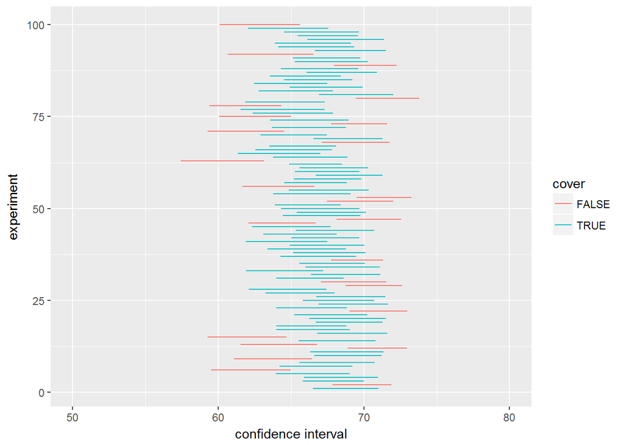

```r
#set the seed
set.seed(90)

#initialize the for loop
CIsimulation <- data.frame(lower=rep(0,100), upper=rep(0,100))


#run the for loop
for(i in 1:100){
    samp <- sample_n(gap2007, size=25)
    CIsimulation[i,] <- t.test(samp$lifeExp, conf.level=0.68)$conf.int
}


CIsimulation <- CIsimulation %>% mutate(experiment = c(1:100), cover = (lower < 67.00742) & (upper > 67.00742))

ggplot(CIsimulation, aes(y=experiment, x=lower, color=cover)) +
    geom_segment(aes(x=lower, xend=upper, y=experiment, yend=experiment)) +
    labs(x="confidence interval") +
    lims(x=c(50,80))
```

9c

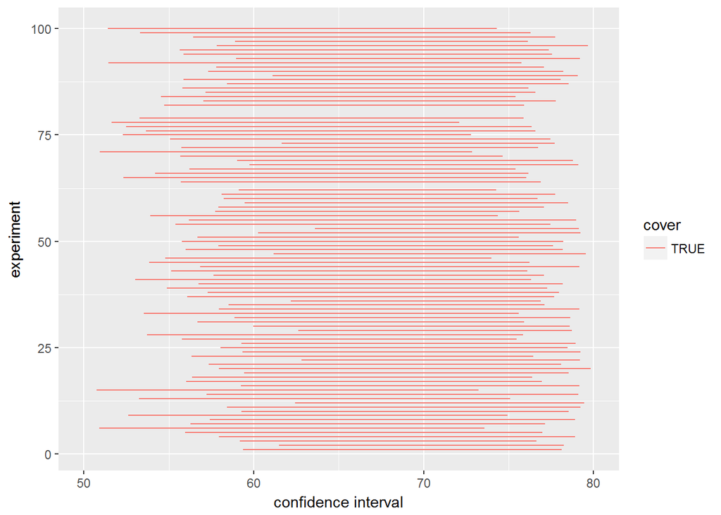

```r
#set the seed
set.seed(90)

#initialize the for loop
CIsimulation <- data.frame(lower=rep(0,100), upper=rep(0,100))


#run the for loop
for(i in 1:100){
    samp <- sample_n(gap2007, size=25)
    CIsimulation[i,] <- t.test(samp$lifeExp, conf.level=0.9997)$conf.int
}


CIsimulation <- CIsimulation %>% mutate(experiment = c(1:100), cover = (lower < 67.00742) & (upper > 67.00742))

ggplot(CIsimulation, aes(y=experiment, x=lower, color=cover)) +
    geom_segment(aes(x=lower, xend=upper, y=experiment, yend=experiment)) +
    labs(x="confidence interval") +
    lims(x=c(50,80))
```

Increasing % confidence means we are more likely to get an interval which captures the true mean but the size of the interval gets bigger. The greater the confidence level, the greater our confidence that the CI covers the population parameter but the wider (and less useful) the interval. Why 95%? Tradition.

## Confidence & Prediction Intervals for Regression Models

```r
PopMod <- lm(lifeExp ~ log(gdpPercap), data=gap2007)
PopMod$coef
```

```
##    (Intercept) log(gdpPercap)
##       4.949612       7.202802
```

```r
summary(PopMod)
```

```
##
## Call:
## lm(formula = lifeExp ~ log(gdpPercap), data = gap2007)
##
## Residuals:
##     Min      1Q  Median      3Q     Max
## -25.947  -2.661   1.215   4.469  13.115
##
## Coefficients:
##                Estimate Std. Error t value Pr(>|t|)
## (Intercept)      4.9496     3.8577   1.283    0.202
## log(gdpPercap)   7.2028     0.4423  16.283   <2e-16 ***
## ---
## Signif. codes:  0 '***' 0.001 '**' 0.01 '*' 0.05 '.' 0.1 ' ' 1
##
## Residual standard error: 7.122 on 140 degrees of freedom
## Multiple R-squared:  0.6544, Adjusted R-squared:  0.652
## F-statistic: 265.2 on 1 and 140 DF,  p-value: < 2.2e-16
```

### Exercise 10

```r
set.seed(60)
samp50 <- sample_n(gap2007, size=50)
sampMod <- lm(lifeExp ~ log(gdpPercap), data=samp50)
summary(sampMod)
```

```
##
## Call:
## lm(formula = lifeExp ~ log(gdpPercap), data = samp50)
##
## Residuals:
##      Min       1Q   Median       3Q      Max
## -22.7163  -2.7433   0.9611   4.2167  12.8711
##
## Coefficients:
##                Estimate Std. Error t value Pr(>|t|)
## (Intercept)      3.9392     6.5152   0.605    0.548
## log(gdpPercap)   7.3636     0.7482   9.842 4.26e-13 ***
## ---
## Signif. codes:  0 '***' 0.001 '**' 0.01 '*' 0.05 '.' 0.1 ' ' 1
##
## Residual standard error: 6.775 on 48 degrees of freedom
## Multiple R-squared:  0.6687, Adjusted R-squared:  0.6618
## F-statistic: 96.86 on 1 and 48 DF,  p-value: 4.256e-13
```

10a. $R^2 = 0.6687$ which means 66.87% of the variability in the data can be explained by our model

10b. $\hat{\beta_0} = 3.93$ and $\hat{\beta_1} = 7.3636$

10c. 95% CI

```r
#$\hat{\beta_0}$
3.93 + 2*6.5152
```

```
## [1] 16.9604
```

```r
3.93 - 2*6.5152
```

```
## [1] -9.1004
```

```r
7.3636 + 2*0.7482
```

```
## [1] 8.86
```

```r
7.3636 - 2*0.7482
```

```
## [1] 5.8672
```

```r
confint(sampMod, level=0.95)
```

```
##                    2.5 %    97.5 %
## (Intercept)    -9.160472 17.038776
## log(gdpPercap)  5.859247  8.867894
```

Yes, the interval for the GDP coef is above 0

### Exercise 11

```r
3.93 + 7.3636 *log(42951.65)
```

```
## [1] 82.48364
```

```r
gap2007 %>% filter(country=="United States")
```

```
## # A tibble: 1 x 6
##         country continent  year lifeExp       pop gdpPercap
##          <fctr>    <fctr> <int>   <dbl>     <int>     <dbl>
## 1 United States  Americas  2007  78.242 301139947  42951.65
```

```r
predict(sampMod, newdata=data.frame(gdpPercap=42951.65),

interval="confidence", level=0.95)
```

```
##        fit     lwr      upr
## 1 82.49247 78.8506 86.13434
```

```r
predict(sampMod, newdata=data.frame(gdpPercap=42951.65),
    interval="prediction", level=0.95)
```

```
##        fit      lwr      upr
## 1 82.49247 68.39238 96.59256
```

### Exercise 12

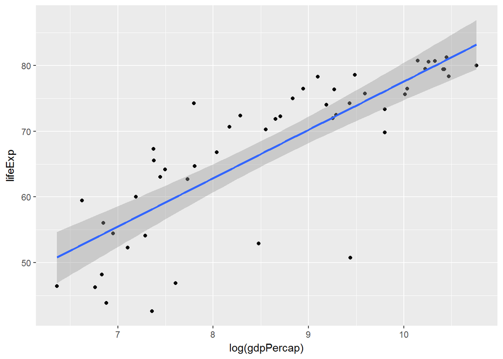

```r
samp50 %>% ggplot(aes(x = log(gdpPercap), y = lifeExp)) + geom_point() + geom_smooth(method = 'lm')
```

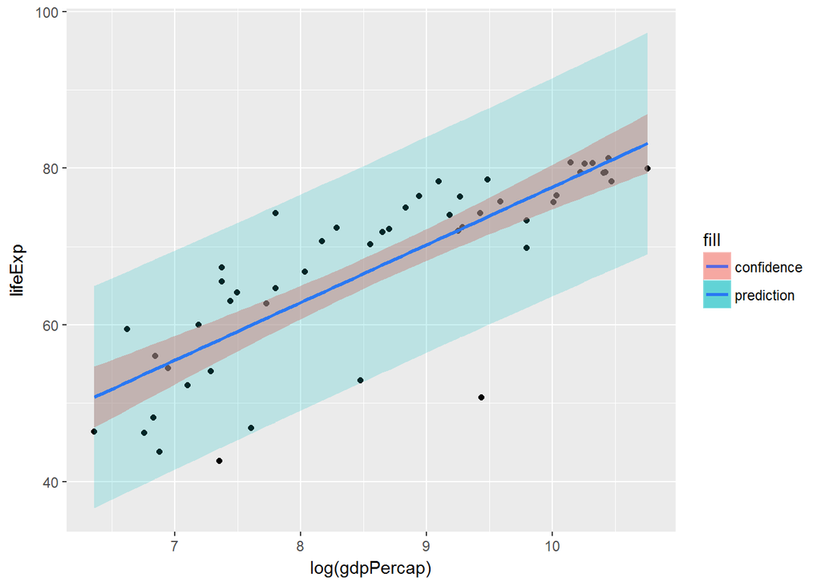

```r
PredInt = data.frame(samp50, predict(sampMod, newdata=data.frame(gdpPercap=samp50$gdpPercap),
    interval = "prediction"))

#Plot model with confidence and prediction bands
ggplot(PredInt, aes(x=log(gdpPercap), y=lifeExp)) +
    geom_point() +
    geom_smooth(method="lm", aes(fill="confidence"), alpha = 0.5) +
    geom_ribbon(aes(y=fit, ymin=lwr, ymax=upr, fill="prediction"), alpha=0.2)
```

## More Practice with Models and Confidence Intervals

### Exercise 13

```r
yeargap <- gapminder %>% filter(year == 1952 | year == 2007)
```

```r
yeargap$year <- as.factor(yeargap$year)
```

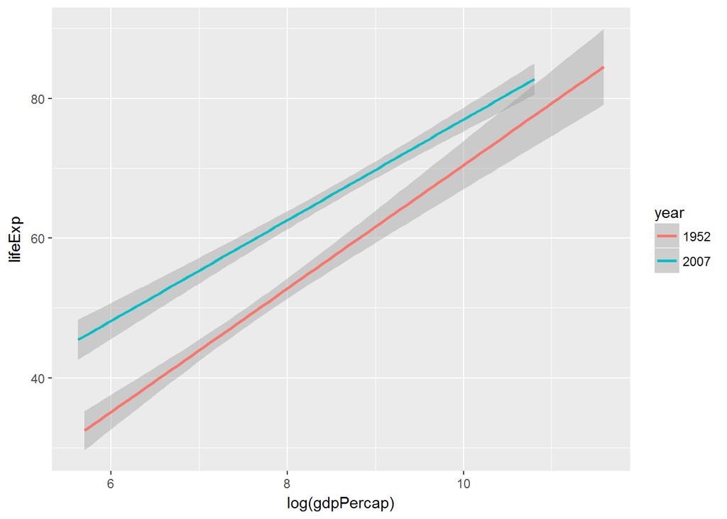

```r
yeargap %>% ggplot(aes(y = lifeExp, x = log(gdpPercap), color = year)) + geom_smooth(method = 'lm')
```

```r
yearmod <- lm(lifeExp ~ log(gdpPercap) + year, yeargap)
summary(yearmod)
```

```
##
## Call:
## lm(formula = lifeExp ~ log(gdpPercap) + year, data = yeargap)
##
## Residuals:
##      Min       1Q   Median       3Q      Max
## -25.8265  -4.2775   0.5244   5.8996  13.6033
##
## Coefficients:
##                Estimate Std. Error t value Pr(>|t|)
## (Intercept)    -10.0583     2.9501  -3.409 0.000746 ***
## log(gdpPercap)   7.8020     0.3799  20.536  < 2e-16 ***
## year2007         9.8450     0.9950   9.894  < 2e-16 ***
## ---
## Signif. codes:  0 '***' 0.001 '**' 0.01 '*' 0.05 '.' 0.1 ' ' 1
##
## Residual standard error: 7.696 on 281 degrees of freedom
## Multiple R-squared:  0.7419, Adjusted R-squared:  0.7401
## F-statistic:   404 on 2 and 281 DF,  p-value: < 2.2e-16
```

```r
#95% CI for 2007

7.8 + 2*0.3799
```

```
## [1] 8.5598
```

```r
7.8 - 2*0.3799
```

```
## [1] 7.0402
```

```r
-10.05+ 9.84 + 2*(2.95+0.9950)
```

```
## [1] 7.68
```

```r
-10.05+ 9.84 - 2*(2.95+0.9950)
```

```
## [1] -8.1
```

```r
#95% CI in 1952
-10.05 + 2*(2.95)
```

```
## [1] -4.15
```

```r
-10.05 - 2*(2.95)
```

```
## [1] -15.95
```

```r
#95% CI difference 2007-1952
 9.84 + 2*(0.9950)
```

```
## [1] 11.83
```

```r
 9.84 - 2*(0.9950)
```

```
## [1] 7.85
```

```r
AAgap <- gap2007 %>% filter(continent == 'Americas' | continent == 'Asia')
```

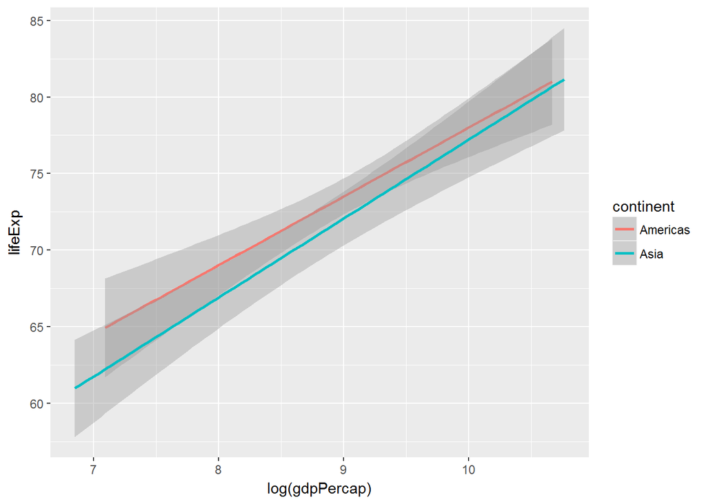

```r
AAgap %>% ggplot(aes(y = lifeExp, x = log(gdpPercap), color = continent)) + geom_smooth(method = 'lm')
```

```r
AAmod <- lm(lifeExp ~ log(gdpPercap) + continent, AAgap)
summary(AAmod)
```

```
##
## Call:
## lm(formula = lifeExp ~ log(gdpPercap) + continent, data = AAgap)
##
## Residuals:
##      Min       1Q   Median       3Q      Max
## -17.5928  -1.4674   0.1152   2.5441   8.2293
##
## Coefficients:
##                Estimate Std. Error t value Pr(>|t|)
## (Intercept)     28.4335     4.7140   6.032 1.43e-07 ***
## log(gdpPercap)   5.0075     0.5146   9.731 1.47e-13 ***
## continentAsia   -1.4740     1.0938  -1.348    0.183
## ---
## Signif. codes:  0 '***' 0.001 '**' 0.01 '*' 0.05 '.' 0.1 ' ' 1
##
## Residual standard error: 4.089 on 55 degrees of freedom
## Multiple R-squared:  0.6491, Adjusted R-squared:  0.6363
## F-statistic: 50.87 on 2 and 55 DF,  p-value: 3.109e-13
```

```r
-1.4740 + 2*1.0938
```

```
## [1] 0.7136
```

```r
-1.4740 - 2*1.0938
```

```
## [1] -3.6616
```

No. We don’t have enough evidence to conclude that when controlling for GDP, life expectancies are significantly higher in the Americas than in Asia because 0 lies in the CI.

### Animation

```r
setwd('D:/Math2IndustryBootCamp2017')
for(i in seq(1952,2007,5)){
  #name = paste(as.character(i),'plot.png',sep='')
  #png(name)
  i
  gapminder %>% filter(year==i) %>% ggplot(aes(x = log(gdpPercap), y = lifeExp, color = continent, size = pop)) + geom_point()
  #dev.off()
  }
```